# **FORM - Human Resources Department**

# K-Means Clustering

Author: David Saucedo Date: Oct 5, 2022

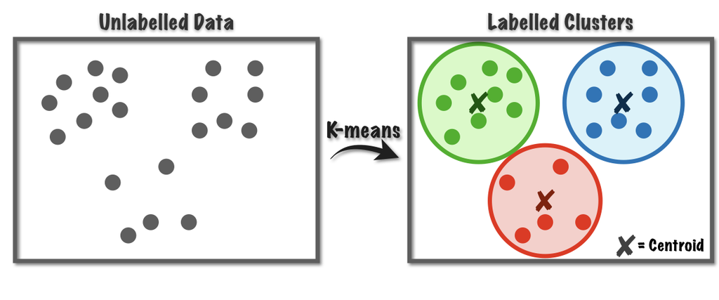

image info

## DEFINITION OF KEY CONCEPTS

**K-Means Clustering** main goal is to identify data patterns and cluster data observations into different groups based on their similarities. It is worth mentioning that K-Means Clustering is an unsupervised clustering algorithm. It is also very useful when working with a dataset characterized by no labels.

#### loading libraries

```r
library(foreign)
library(dplyr)        # data manipulation
library(ggplot2)      # data visualization
library(psych)        # functions for multivariate analysis
library(corrplot)     # correlation plots
library(jtools)       # presentation of regression analysis
library(lmtest)       # diagnostic checks - linear regression analysis
library(car)          # diagnostic checks - linear regression analysis
library(factoextra)   # provides functions to extract and visualize the output of exploratory multivariate data analyses
library(ggfortify)    # data visualization tools for statistical analysis results
library(ggalluvial)   # used to visualize frequency tables involving several categorical variables
```

## DATA CLEANING, TRANSFORMATION, AND ORGANIZATION

#### importing dataset

```r
rh<-read.csv("D:\\Tec21\\CD2001C\\FORM - Datos\\form_rh_datos.csv")
```

#### lets very the structure of the dataset

```r
str(rh)
```

```
## 'data.frame':    113 obs. of  27 variables:
##  $ No..De.Empleado      : int  NA 62 9 33 60 79 81 114 41 23 ...
##  $ APELLIDOS            : chr  "VERA VALDEZ" "CERDA HERNANDEZ" "MORENO SALINAS" "RODRIGUEZ MORENO" ...
##  $ NOMBRE               : chr  "JOSE MANUEL" "KEVIN ARTURO" "HUMBERTO" "NICOLAS DE JESUS" ...
##  $ FECHA.DE.NACIMIENTO  : chr  "12/23/1994" "10/23/2002" "11/3/1995" "1/11/1992" ...
##  $ HOY                  : chr  "9/23/2022" "9/23/2022" "9/23/2022" "9/23/2022" ...
##  $ GENERO               : chr  "MASCULINO" "MASCULINO" "MASCULINO" "MASCULINO" ...
##  $ RFC                  : chr  "VEVM9412238W8" "CEHK0210237V6" "MOSH9511033L4" "ROMN920411QUA" ...
##  $ FECHA.DE.ALTA        : chr  "8/18/2022" "2/18/2022" "1/11/2017" "11/3/2020" ...
##  $ Primer.mes           : int  44822 44640 42776 44168 44638 44743 44750 44762 44340 43866 ...
##  $ X4to.mes             : int  44913 44730 42866 44258 44728 44833 44840 44852 44430 43956 ...
##  $ BAJA                 : int  NA NA NA NA NA 3 3 NA NA NA ...
##  $ PUESTO               : chr  "MANTENIMIENTO" "AYUDANTE GENERAL" "AYUDANTE GENERAL" "AYUDANTE GENERAL" ...
##  $ DEPARTAMENTO         : chr  "" "Ay.flexo" "Cedis" "Cedis" ...
##  $ NO.SEGURO.SOCIAL     : chr  "35149402816" "27170227006" "56149534788" "" ...
##  $ SALARIO.DIARIO.IMSS  : num  181 181 177 177 181 ...
##  $ FACTOR.CRED.INFONAVIT: chr  "N/A" "N/A" "" "" ...
##  $ NO..CREDITO.INFONAVIT: chr  "N/A" "N/A" "" "" ...
##  $ LUGAR.DE.NACIMIENTO  : chr  "EBANO, SAN LUIS POTOSI" "MONTERREY, NUEVO LEON" "" "" ...
##  $ CURP                 : chr  "VEVM941223HSPRLN07" "CEHK021023HNLRRVA8" "MOSH951103HVZRLM03" "ROMN920411HCLDRC00" ...
##  $ CALLE                : chr  "MIER Y NORIEGA" "PORTAL GALICIA" "OCEANIA" "TASAJILLO" ...
##  $ NUMERO.INTERNO       : chr  "106B" "219" "" "220" ...
##  $ COLONIA              : chr  "MIRADOR DE SAN ANTONIO" "PORTAL DEL VALLE" "FRACC. OCEANIA BOULEVARES" "EL CACTUS" ...
##  $ MUNICIPIO            : chr  "JUAREZ" "APODACA" "SALTILLO" "RAMOS ARIZPE" ...
##  $ ESTADO               : chr  "NUEVO LEON" "NUEVO LEON" "COAHUILA" "COAHUILA" ...
##  $ CODIGO.POSTAL        : int  67255 66643 25290 25902 66646 67114 66646 66649 66643 66647 ...
##  $ ESTADO.CIVIL         : chr  "MATRIMONIO" "SOLTERIA" "MATRIMONIO" "UNION LIBRE" ...
##  $ TARJETA.CUENTA       : chr  "SANTANDER" "BANORTE" "BANORTE" "BANORTE" ...
```

#### select columns / variables

```r
rh_alt<-rh %>% select(-one_of('No..De.Empleado','APELLIDOS','NOMBRE','RFC','FECHA.DE.ALTA','Primer.mes','X4to.mes','BAJA','NO.SEGURO.SOCIAL','FACTOR.CRED.INFONAVIT','NO..CREDITO.INFONAVIT','LUGAR.DE.NACIMIENTO',
                              'CURP','CALLE','NUMERO.INTERNO','COLONIA','CODIGO.POSTAL','TARJETA.CUENTA'))
```

#### lets rename the selected columns / variables

```r
colnames(rh_alt)<-c('fecha_nacimiento','fecha_actual','genero','puesto','depto','salario_diario','mpio','estado','estado_civil')
```

#### lets convert “fecha_nacimiento” to date format

```r
rh_alt$fecha_nacimiento<-as.Date(rh_alt$fecha_nacimiento,format="%m/%d/%Y")
rh_alt$fecha_actual<-as.Date(rh_alt$fecha_actual,format="%m/%d/%Y")
```

#### lets calculate the variable “age” in years so we can realize additional characteristics of “colaboradores”

```r
library(lubridate)
edad<-trunc((rh_alt$fecha_nacimiento %--% rh_alt$fecha_actual) / years(1)) # %--% creates a time interval based on as.date() format
rh_alt$edad<-edad
```

#### lets convert character variables to factor so we can display descriptive statistics

```r
rh_alt$genero<-as.factor(rh_alt$genero)
rh_alt$puesto<-as.factor(rh_alt$puesto)
rh_alt$depto<-as.factor(rh_alt$depto)
rh_alt$mpio<-as.factor(rh_alt$mpio)
rh_alt$estado<-as.factor(rh_alt$estado)
rh_alt$estado_civil<-as.factor(rh_alt$estado_civil)
```

#### lets verify the structure of our rh_alt dataset

```r
str(rh_alt)
```

```
## 'data.frame':    113 obs. of  10 variables:
##  $ fecha_nacimiento: Date, format: "1994-12-23" "2002-10-23" ...
##  $ fecha_actual    : Date, format: "2022-09-23" "2022-09-23" ...
##  $ genero          : Factor w/ 2 levels "FEMENINO","MASCULINO": 2 2 2 2 1 1 1 2 1 1 ...
##  $ puesto          : Factor w/ 19 levels "AYUDANTE GENERAL",..: 12 1 1 1 1 1 1 1 1 1 ...
##  $ depto           : Factor w/ 22 levels "","Ay.flexo",..: 1 2 4 4 6 6 6 7 9 17 ...
##  $ salario_diario  : num  181 181 177 177 181 ...
##  $ mpio            : Factor w/ 9 levels "CA\xd1ADA BLANCA",..: 4 2 8 7 2 3 2 2 2 2 ...
##  $ estado          : Factor w/ 2 levels "COAHUILA","NUEVO LEON": 2 2 1 1 2 2 2 2 2 2 ...
##  $ estado_civil    : Factor w/ 4 levels "DIVORCIO","MATRIMONIO",..: 2 3 2 4 3 3 4 2 2 2 ...
##  $ edad            : num  27 19 26 30 45 56 35 32 50 54 ...
```

```r
summary(rh_alt)
```

```
##  fecha_nacimiento      fecha_actual              genero                puesto
##  Min.   :1949-11-21   Min.   :2022-09-23   FEMENINO :61   AYUDANTE GENERAL:67
##  1st Qu.:1977-04-20   1st Qu.:2022-09-23   MASCULINO:52   COSTURERA       :10
##  Median :1989-01-22   Median :2022-09-23                  CHOFER          : 5
##  Mean   :1986-09-01   Mean   :2022-09-23                  SOLDADOR        : 5
##  3rd Qu.:1997-01-03   3rd Qu.:2022-09-23                  RESIDENTE       : 4
##  Max.   :2022-02-23   Max.   :2022-09-23                  SUPERVISOR      : 4
##  NA's   :1                                                (Other)         :18
##                    depto    salario_diario             mpio           estado
##                       :40   Min.   :1.440e+02   APODACA  :72   COAHUILA  :  9
##  Produccion Retorn    :10   1st Qu.:1.770e+02   JUAREZ   :10   NUEVO LEON:104
##  Costura              : 7   Median :1.810e+02   PESQUERIA: 9
##  Produccion Carton MDL: 7   Mean   :1.346e+07   GUADALUPE: 6
##  Stabilus             : 7   3rd Qu.:1.810e+02   SALTILLO : 5
##  Cedis                : 6   Max.   :1.517e+09   MONTERREY: 4
##  (Other)              :36                       (Other)  : 7
##       estado_civil      edad
##  DIVORCIO   : 3    Min.   : 0.00
##  MATRIMONIO :44    1st Qu.:25.00
##  SOLTERIA   :46    Median :33.50
##  UNION LIBRE:20    Mean   :35.55
##                    3rd Qu.:45.00
##                    Max.   :72.00
##                    NA's   :1
```

#### remove row no. 53 because it shows a missing value

```r
rh_alt<-rh_alt[-c(53),] #
summary(rh_alt) # no missing values
```

```
##  fecha_nacimiento      fecha_actual              genero                puesto
##  Min.   :1949-11-21   Min.   :2022-09-23   FEMENINO :61   AYUDANTE GENERAL:66
##  1st Qu.:1977-04-20   1st Qu.:2022-09-23   MASCULINO:51   COSTURERA       :10
##  Median :1989-01-22   Median :2022-09-23                  CHOFER          : 5
##  Mean   :1986-09-01   Mean   :2022-09-23                  SOLDADOR        : 5
##  3rd Qu.:1997-01-03   3rd Qu.:2022-09-23                  RESIDENTE       : 4
##  Max.   :2022-02-23   Max.   :2022-09-23                  SUPERVISOR      : 4
##                                                           (Other)         :18
##                    depto    salario_diario             mpio           estado
##                       :39   Min.   :1.440e+02   APODACA  :71   COAHUILA  :  9
##  Produccion Retorn    :10   1st Qu.:1.770e+02   JUAREZ   :10   NUEVO LEON:103
##  Costura              : 7   Median :1.810e+02   PESQUERIA: 9
##  Produccion Carton MDL: 7   Mean   :1.358e+07   GUADALUPE: 6
##  Stabilus             : 7   3rd Qu.:1.810e+02   SALTILLO : 5
##  Cedis                : 6   Max.   :1.517e+09   MONTERREY: 4
##  (Other)              :36                       (Other)  : 7
##       estado_civil      edad
##  DIVORCIO   : 3    Min.   : 0.00
##  MATRIMONIO :44    1st Qu.:25.00
##  SOLTERIA   :46    Median :33.50
##  UNION LIBRE:19    Mean   :35.55
##                    3rd Qu.:45.00
##                    Max.   :72.00
##
```

#### replace “edad” 0 yrs old with the mean

```r
rh_alt$edad<-replace(rh_alt$edad,rh_alt$edad==0,36)
```

#### lets display data visualization plots so we can identify relevant insights from our rh_alt dataset

```r
tapply(rh_alt$salario_diario,
       list(rh_alt$genero,rh_alt$estado_civil), mean)
```

```
##           DIVORCIO   MATRIMONIO    SOLTERIA UNION LIBRE
## FEMENINO    180.68 1.842905e+02 176718.0296    180.9669
## MASCULINO   176.72 6.594489e+07    176.1038    180.0200
```

#### replace the “outlier” of salario_diario with the median

```r
rh_alt$salario_diario<-replace(rh_alt$salario_diario,rh_alt$salario_diario>1000000,181)
```

#### exporting cleaned dataset

```r
# write.csv(produccion_alt,"D:\\Tec21\\CD2001C\\FORM - Datos\\form_rh_final.csv", row.names=FALSE)
```

#### lets explore k-means clustering related to “edad” in years

#### it is worth mentioning that k-means clustering analysis can only include quantitative variables

```r
rh_edad<-rh_alt %>% select(genero,estado_civil,salario_diario,edad)
```

#### The normalizing of a dataset (quantitative variables) using the mean value and standard deviation is performed by scale()

```r
rh_edad_norm<-scale(rh_edad[3:4])
```

#### Use fviz function to view Elbow Plot for visualizing optimal number of clusters

#### fviz_nbclust() helps to determine and visualize the optimal number of clusters

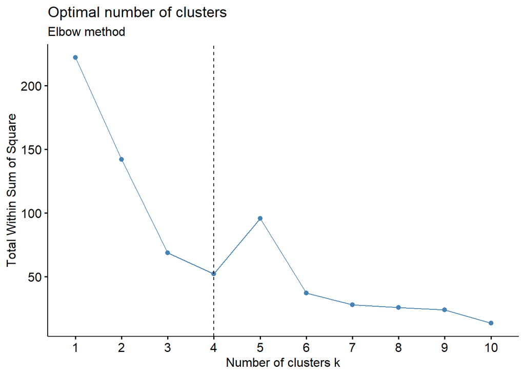

```r
fviz_nbclust(rh_edad_norm, kmeans, method="wss")+ # wss method considers total within sum of square
  geom_vline(xintercept=4, linetype=2)+           # optimal number of clusters is computed with the default method = "euclidean"
  labs(subtitle = "Elbow method")
```

### How to Select the Optimal Number of Clusters?

The within-cluster sum of squares is a measure of the variability of the observations within each cluster. In general, a cluster that has a small sum of squares is more compact than a cluster that has a large sum of squares. Generally, we select the optimal value of K when we see SSE starts to flatten out and forms an elbow shape.

#### visualize the clusters’ information. Briefly, you can detect how each dataset’s observation corresponds to a specific cluster.

```r
edad_cluster1<-kmeans(rh_edad_norm,4)
edad_cluster1
```

```
## K-means clustering with 4 clusters of sizes 37, 9, 56, 10
##
## Cluster means:
##   salario_diario       edad
## 1      0.4395437  1.0178149
## 2     -1.1537412  0.9181994
## 3      0.1068132 -0.6521487
## 4     -1.1860986 -0.9402621
##
## Clustering vector:
##   1   2   3   4   5   6   7   8   9  10  11  12  13  14  15  16  17  18  19  20
##   3   3   3   3   1   1   3   3   2   2   4   4   2   4   2   4   3   1   4   2
##  21  22  23  24  25  26  27  28  29  30  31  32  33  34  35  36  37  38  39  40
##   3   4   1   1   4   3   1   3   3   3   1   3   3   3   3   3   1   2   1   1
##  41  42  43  44  45  46  47  48  49  50  51  52  54  55  56  57  58  59  60  61
##   3   1   3   3   3   3   3   4   4   2   3   3   3   3   3   3   1   3   3   3
##  62  63  64  65  66  67  68  69  70  71  72  73  74  75  76  77  78  79  80  81
##   1   3   3   1   3   3   1   3   3   1   3   3   1   1   1   1   1   1   2   1
##  82  83  84  85  86  87  88  89  90  91  92  93  94  95  96  97  98  99 100 101
##   1   1   3   3   2   1   1   1   3   3   4   1   1   3   3   1   3   1   3   3
## 102 103 104 105 106 107 108 109 110 111 112 113
##   3   1   3   3   3   3   3   3   1   1   1   1
##
## Within cluster sum of squares by cluster:
## [1] 84.770578  3.720765 19.712774  1.384789
##  (between_SS / total_SS =  50.6 %)
##
## Available components:
##
## [1] "cluster"      "centers"      "totss"        "withinss"     "tot.withinss"
## [6] "betweenss"    "size"         "iter"         "ifault"
```

#### visualize clustering results

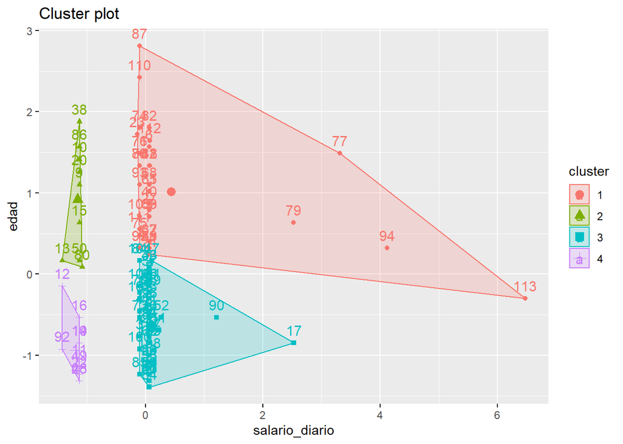

```r
fviz_cluster(edad_cluster1,data=rh_edad_norm)
```

#### lets add the estimated clusters’ information to the original dataset so we can interpret the results

```r
rh_alt1<-rh_alt
rh_alt1$Clusters<-edad_cluster1$cluster
```

#### lets create a dataset so we can identify some characteristics of “edad” by cluster

```r
rh_alt2<-rh_alt1 %>% group_by(Clusters) %>% summarise(edad=max(edad)) %>% arrange(desc(edad))
```

#### group the clusters by name

```r
rh_alt1$Cluster_Names<-factor(rh_alt1$Clusters,levels = c(1,2,3,4),
                              labels=c("Jubiliación", "Avanzada", "Adulta", "Joven"))
```

#### group the clusters by cluster names and Summarize the Columns

```r
rh_alt3 <- rh_alt1 %>% group_by(Cluster_Names) %>% summarize(edad_años=max(edad),
                                                             salario_imss=mean(salario_diario),
                                                             Count=n())
```

#### use table format to display the clusters information

```r
clusters<-as.data.frame(rh_alt3)
clusters
```

```
##   Cluster_Names edad_años salario_imss Count
## 1   Jubiliación        72     189.8403    37
## 2      Avanzada        60     150.9733     9
## 3        Adulta        38     181.7236    56
## 4         Joven        34     150.1840    10
```

#### lets plot the number of data observations by clusters names

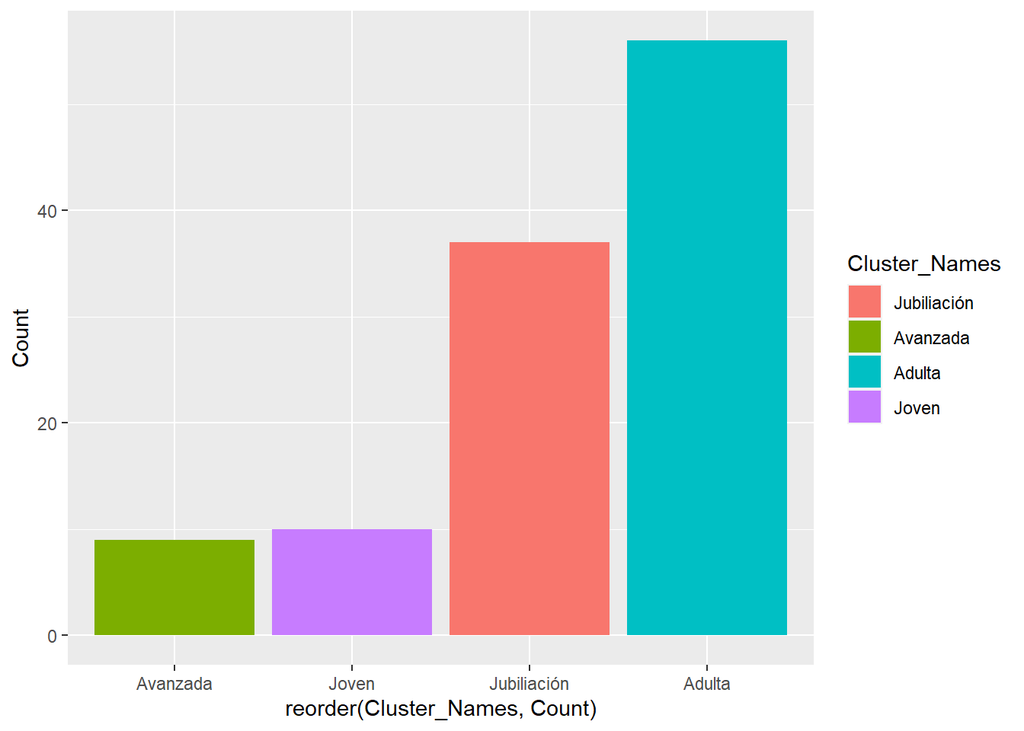

```r
ggplot(rh_alt3,aes(x=reorder(Cluster_Names,Count),y=Count,fill=Cluster_Names)) +
  geom_bar(stat="identity")
```

#### lets visualize the range of “edad” by clusters’ names

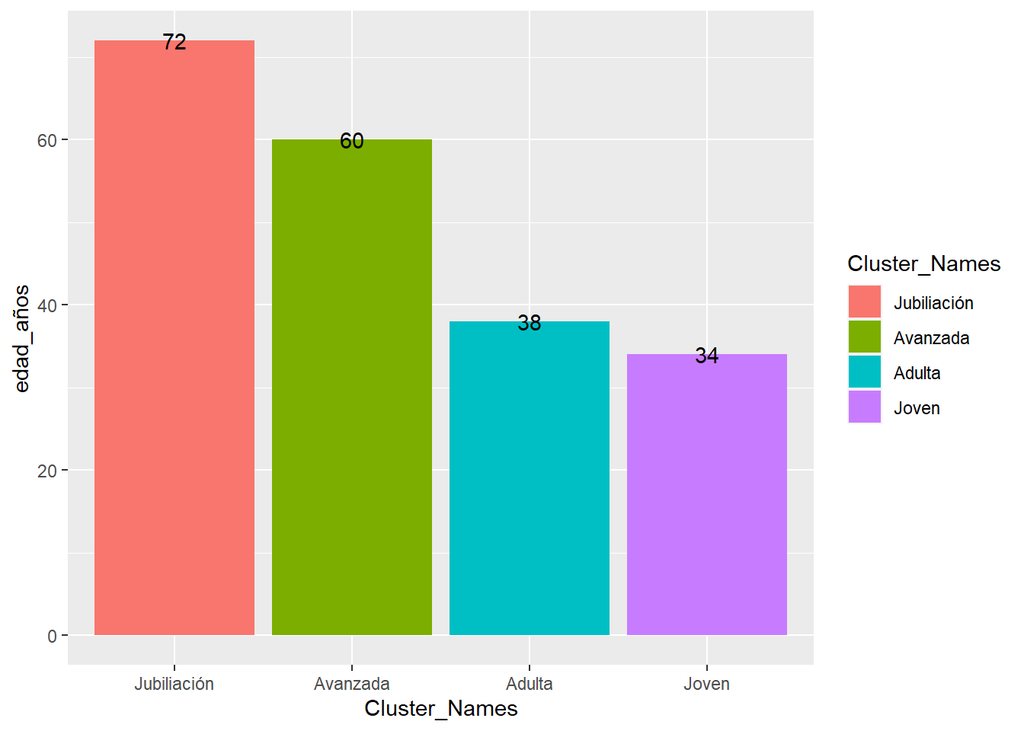

```r
ggplot(rh_alt3, aes(x=Cluster_Names,y=edad_años,fill= Cluster_Names,label=round(edad_años,digits=2))) +
  geom_col() +
  geom_text()
```

#### lets visualize the range of “salario_imss” by clusters’ names

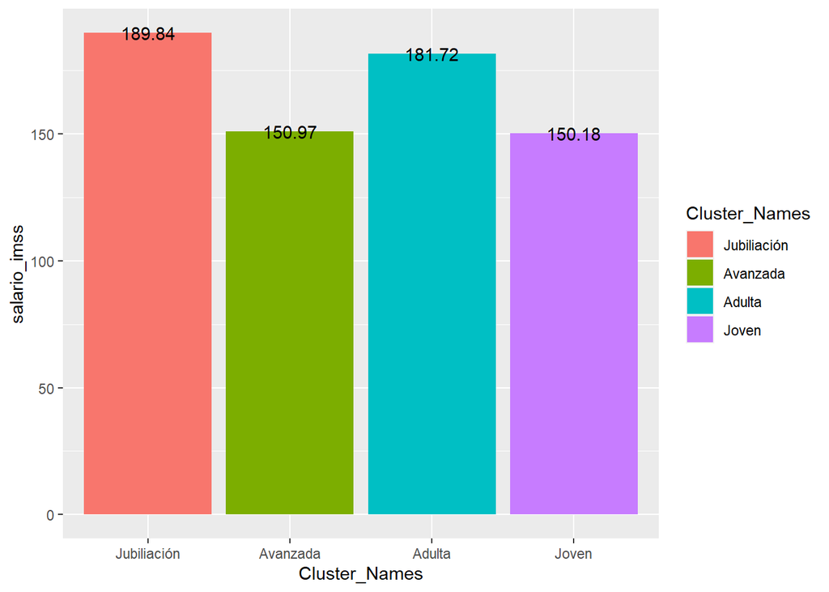

```r
ggplot(rh_alt3,aes(x=Cluster_Names,y=salario_imss,fill= Cluster_Names,label=round(salario_imss,digits=2))) +
  geom_col() +
  geom_text()
```

#### lets visualize dispersion of “edad” by clusters names

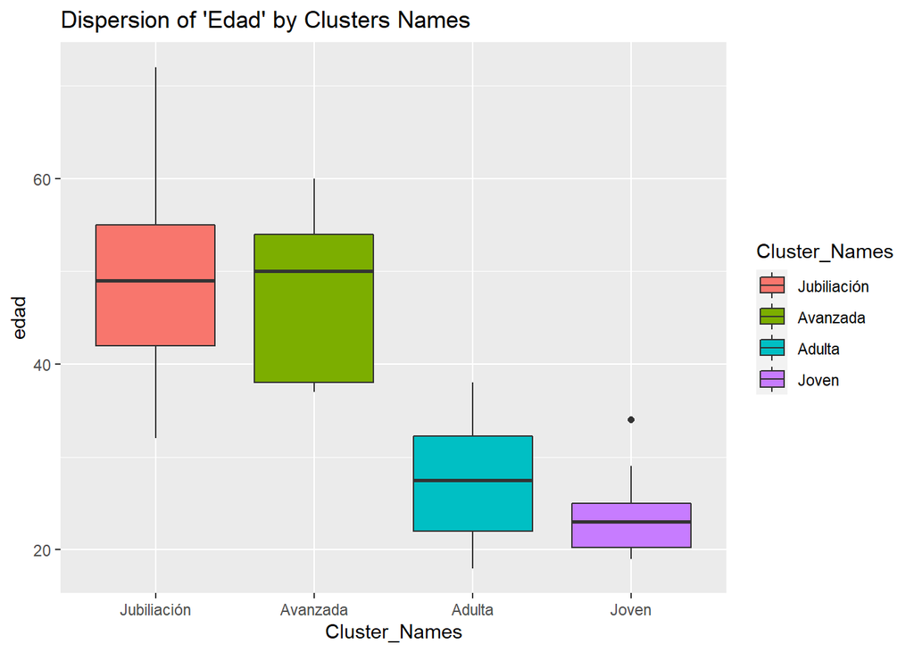

```r
ggplot(rh_alt1, aes(x=Cluster_Names, y=edad, fill=Cluster_Names)) +
  geom_boxplot()+
  ggtitle("Dispersion of 'Edad' by Clusters Names")
```

#### lets visualize dispersion of “salario_diario” by clusters names

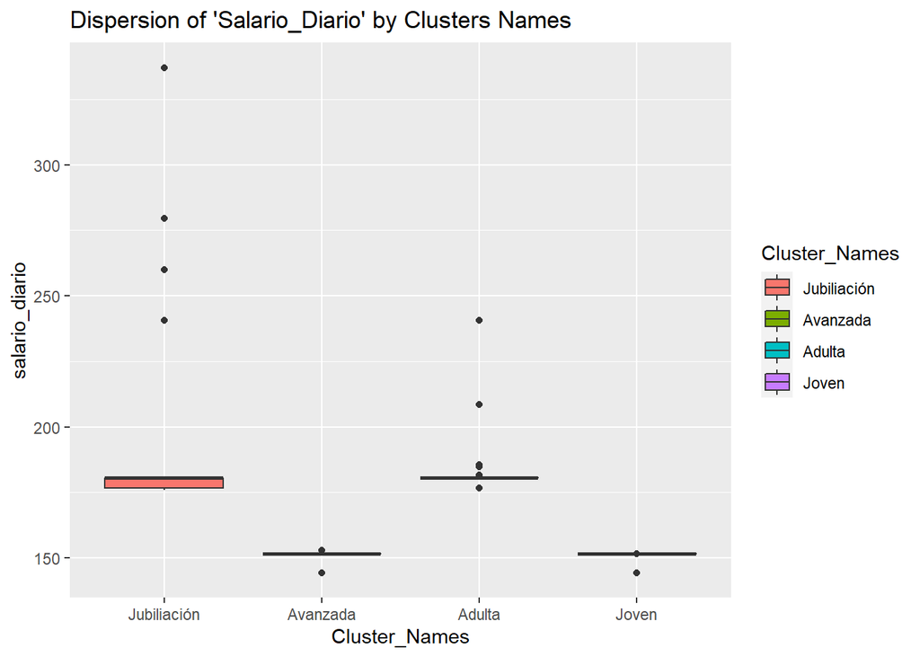

```r
ggplot(rh_alt1, aes(x=Cluster_Names, y=salario_diario, fill=Cluster_Names)) +
  geom_boxplot()+
  ggtitle("Dispersion of 'Salario_Diario' by Clusters Names")
```

#### we can also display the relationship between “edad” and “salario_diario” by clusters

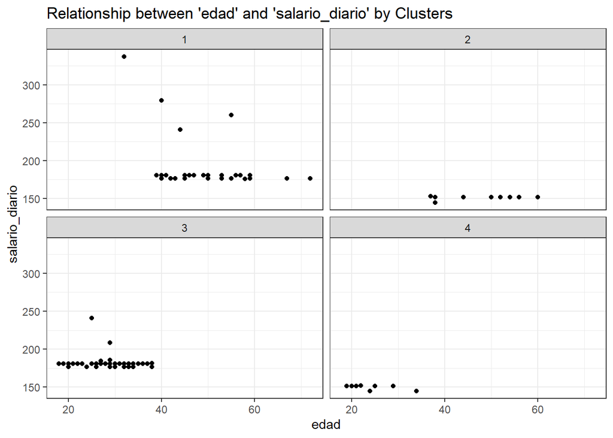

```r
ggplot(rh_alt1, mapping=aes(x=edad,y=salario_diario)) +
  geom_point() +
  facet_wrap(~Clusters) +
  theme_bw()+
  ggtitle("Relationship between 'edad' and 'salario_diario' by Clusters")
```

#### we can also display “genero” by cluster names

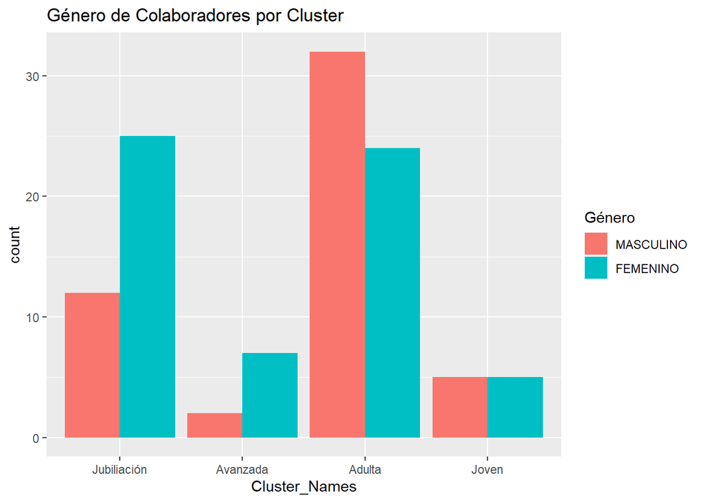

```r
ggplot(rh_alt1, aes(Cluster_Names, fill=factor(genero,levels=rev(levels(genero))))) +
  geom_bar(position="dodge")+
  scale_fill_discrete('Género')+
  ggtitle("Género de Colaboradores por Cluster")
```

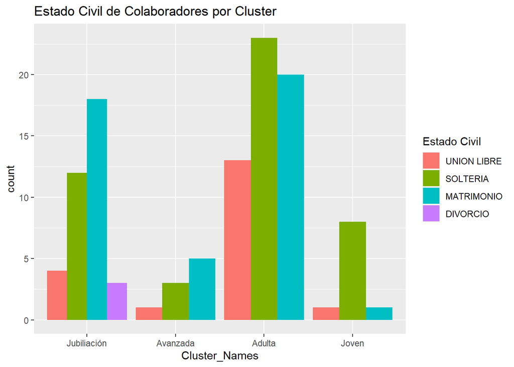

```r
ggplot(rh_alt1, aes(Cluster_Names, fill=factor(estado_civil,levels=rev(levels(estado_civil))))) +
  geom_bar(position="dodge")+
  scale_fill_discrete('Estado Civil')+
  ggtitle("Estado Civil de Colaboradores por Cluster")
```

#### lets visualize “puesto” by cluster names

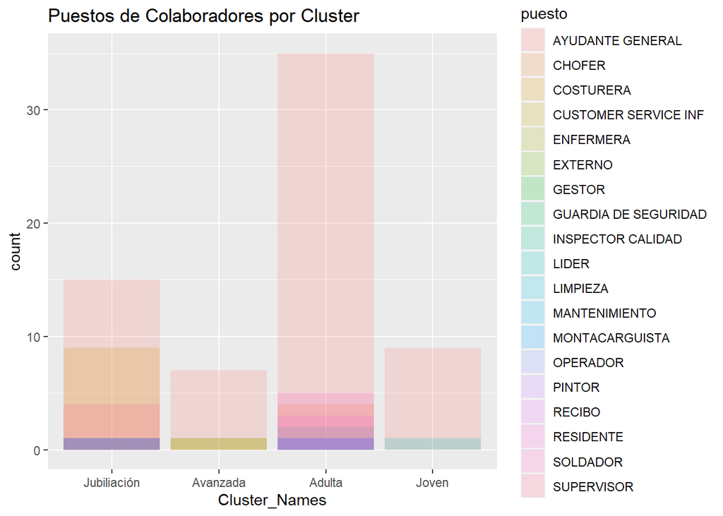

```r
ggplot(rh_alt1, mapping=aes(x=Cluster_Names, fill=puesto)) +
  geom_bar(alpha = 1/5, position="identity")+
  ggtitle("Puestos de Colaboradores por Cluster")
```

#### lets get specific characteristics of Cluster Adulta

```r
rh_alt4<-subset(rh_alt1,Clusters==3,select=c("Cluster_Names","genero","puesto","estado_civil","edad","salario_diario"))
rh_alt4<-rh_alt4 %>% group_by(puesto) %>% summarise(edad=mean(edad),salario_diario=mean(salario_diario),Count=n())
rh_alt4<-as.data.frame(rh_alt4)
rh_alt4<-arrange(rh_alt4,desc(Count))
rh_alt4<-mutate(rh_alt4,edad=round(edad,0),salario_diario=round(salario_diario,0))
rh_alt4
```

```
##                  puesto edad salario_diario Count
## 1      AYUDANTE GENERAL   26            182    35
## 2              SOLDADOR   28            180     5
## 3                CHOFER   29            179     4
## 4             RESIDENTE   35            178     3
## 5     INSPECTOR CALIDAD   28            195     2
## 6  CUSTOMER SERVICE INF   38            177     1
## 7             ENFERMERA   20            177     1
## 8              LIMPIEZA   31            181     1
## 9         MANTENIMIENTO   27            181     1
## 10       MONTACARGUISTA   33            181     1
## 11            OPERADOR    27            181     1
## 12               RECIBO   24            177     1
```

#### we can also explore several associations between categorical variables across clusters_names

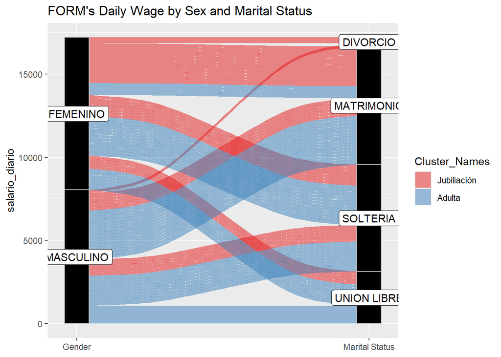

```r
rh_alt5<-rh_alt1 %>% filter(Clusters==1 | Clusters==3) %>% arrange(Clusters)
ggplot(as.data.frame(rh_alt5),
       aes(y=salario_diario, axis1=genero, axis2=estado_civil)) +
  geom_alluvium(aes(fill=Cluster_Names), width = 1/12) +
  geom_stratum(width = 1/12, fill = "black", color = "grey") +
  geom_label(stat = "stratum", aes(label = after_stat(stratum))) +
  scale_x_discrete(limits = c("Gender", "Marital Status"), expand = c(.05, .05)) +
  scale_fill_brewer(type = "qual", palette = "Set1") +
  ggtitle("FORM's Daily Wage by Sex and Marital Status")
```

#### we can also explore several associations between categorical variables across clusters_names

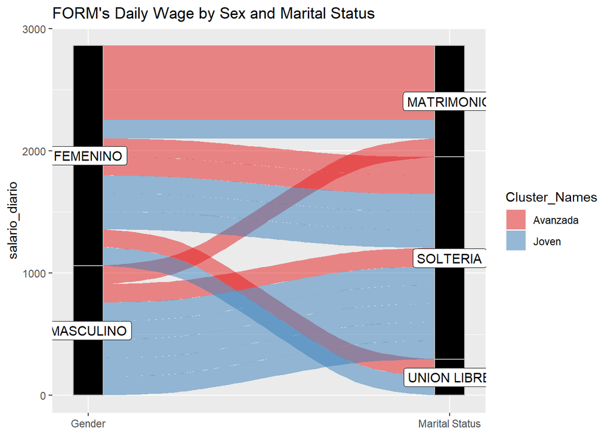

```r
rh_alt6<-rh_alt1 %>% filter(Clusters==2 | Clusters==4) %>% arrange(Clusters)
ggplot(as.data.frame(rh_alt6),
       aes(y=salario_diario, axis1=genero, axis2=estado_civil)) +
  geom_alluvium(aes(fill=Cluster_Names), width = 1/12) +
  geom_stratum(width = 1/12, fill = "black", color = "grey") +
  geom_label(stat = "stratum", aes(label = after_stat(stratum))) +
  scale_x_discrete(limits = c("Gender", "Marital Status"), expand = c(.05, .05)) +
  scale_fill_brewer(type = "qual", palette = "Set1") +
  ggtitle("FORM's Daily Wage by Sex and Marital Status")
```

## References:

K-Means Clustering Explained Simply https://towardsdatascience.com/explain-ml-in-a-simple-way-k-means-clustering-e925d019743b

K-Means: A Complete Introduction https://towardsdatascience.com/k-means-a-complete-introduction-1702af9cd8c